# Módulo 4 — Modelos de Comunidade e de Espécies Conjuntas

Pipeline de análise de armadilhas fotográficas do Snapshot Brasil

**ImportanteComo usar este notebook**

# 1 Cinco métodos, lado a lado

O pipeline estima as relações espécie–hábitat de cinco formas diferentes, cada uma fazendo suposições distintas. Antes de mergulhar em qualquer uma delas, aqui está a comparação completa para que as seções individuais a seguir possam ser lidas em relação a este mapa.

| Método | Correção de detecção? | Agrupa entre espécies? | Resposta |
| --- | --- | --- | --- |
| **GLM (ingênuo)** | Não | Não | presença/ausência, ajustado como uma **regressão logística** — o mesmo desenho da ocupação de espécie única, mas sem submodelo de detecção, então um “0” sempre significa ausente em vez de possivelment… |
| **Ocupação de espécie única** | Sim | Não | ocupação ψ |
| **Royle–Nichols** | Sim (via abundância) | Não | abundância λ |
| **Comunidade** | Sim | Sim (agrupamento parcial) | ocupação ψ |
| **GJAM** | via offset de esforço | Sim (conjunto) | abundância + co-ocorrência |

Mostrá-los juntos responde a uma pergunta que os alunos sempre fazem: *a escolha do modelo muda a conclusão ecológica?* A resposta curta, neste conjunto de dados, é que o **sinal e a magnitude aproximada dos efeitos fortes são robustos**, enquanto os **efeitos fracos e as espécies esparsas são onde os métodos divergem** — que é exatamente onde se esperaria que as suposições do método importassem. O restante deste módulo constrói essa comparação um método de cada vez, e depois a revisita por completo na seção final.

# 2 O que este módulo faz

Todo modelo ajustado até agora tratou **uma espécie de cada vez**: um modelo de ocupação separado para a anta, outro para a onça-pintada, e assim por diante (Módulo 3). Essa é a ferramenta certa para a estimativa mais defensável de uma única espécie rica em dados, mas tem dois pontos cegos.

1. **Espécies esparsas obtêm estimativas instáveis.** Uma espécie detectada em poucos locais carrega quase nenhuma informação por si só; seus coeficientes de hábitat saem com incerteza enorme, ou nem convergem.
2. **As espécies são modeladas como se fossem independentes.** Na realidade, uma paca e uma jaguatirica compartilham a mesma floresta, e onde uma é encontrada diz algo sobre onde a outra pode estar. Modelos de espécie única descartam essa estrutura.

Este módulo ajusta dois tipos de modelo que abordam esses pontos cegos usando **todas as espécies de uma só vez**:

- Um **modelo de ocupação de comunidade** (Dorazio–Royle, ajustado no JAGS) que mantém a estrutura de detecção/não detecção do Módulo 3, mas permite que os coeficientes de cada espécie sejam extraídos de uma distribuição de comunidade compartilhada. Espécies ricas em dados ancoram a média da comunidade; espécies pobres em dados são puxadas em direção a ela. Isso é **agrupamento parcial** — emprestar força. Dois **traços em nível de espécie** — massa corporal e classe de dieta (carnívoro/onívoro/herbívoro) — explicam parte do *porquê* as espécies diferem, entrando como preditores dos interceptos basais de ocupação e detecção de cada espécie.
- Um **modelo conjunto de distribuição de espécies** (GJAM) que modela as espécies *juntas* e estima, depois de considerar o hábitat compartilhado, quais espécies ainda co-ocorrem mais (ou menos) do que o hábitat sozinho preveria. Essa co-ocorrência residual é o sinal biótico — o “quem tende a ser encontrado com quem” da comunidade.

Ajustamos ambos no conjunto de dados final mesclado das três redes: **1092 locais × 44 espécies × 11 covariáveis de hábitat/clima** (floresta, savana, pastagem, lavoura, vegetação nativa, temperatura, precipitação, status de área protegida, um índice de desenvolvimento de superfície construída, distância à estrada e distância à água — a lista expandida de covariáveis **CAMERA_SET**, adicionando desenvolvimento e as duas camadas de distância, além de lavoura e pastagem ao conjunto original do Módulo 3), com a **máscara de distribuição** fora da área de distribuição do exercício do Módulo 2.2 aplicada. Em seguida, colocamos os cinco métodos do pipeline lado a lado e perguntamos onde concordam, onde divergem e por quê.

**NotaO foco ecológico deste módulo**

Este módulo trata de **ecologia** — a quais hábitats cada espécie responde, e como a comunidade como um todo está estruturada. As *interações* entre espécies (competição, predador–presa, a rede de co-ocorrência) recebem um tratamento breve aqui e um tratamento completo no **Módulo 6 (Interações entre espécies)**. Quando chegarmos à matriz de correlação residual do GJAM, vamos lê-la como um resumo ecológico, não dissecar pares individuais de espécies — essa é a tarefa do Módulo 6.

# 3 Lidando com locais fora da área de distribuição em um modelo de comunidade

O Módulo 3 lidou com espécies fotografadas fora de sua área de distribuição publicada pela IUCN por meio de uma decisão por espécie: para um **zero estrutural** — um local que está tanto fora da área de distribuição *quanto* nunca registrou a espécie — o local foi descartado do modelo daquela espécie, porque um zero garantido ali não é ecologia, é geografia, e enviesa os coeficientes de hábitat. Um local **detectado fora da área de distribuição** (uma foto fora do polígono) sempre foi mantido: uma fotografia supera um mapa de área de distribuição.

Esse recorte por espécie não funciona para um modelo de comunidade. Modelos de comunidade precisam de um **desenho retangular local × espécie** — cada espécie é definida em cada local, porque esse desenho compartilhado é exatamente o que permite ao modelo emprestar força entre espécies. Se recortássemos um conjunto diferente de locais para cada espécie, o retângulo se tornaria irregular e os hiperparâmetros da comunidade não poderiam ser estimados. Então, em vez de descartar locais, tratamos as **células** impossíveis.

Havia três opções (especificação do Módulo 2.2). Usamos a primeira para o modelo de comunidade e a segunda para o GJAM:

1. **Máscara de distribuição no estado latente (modelo de comunidade).** Mantenha cada local. Para uma célula de zero estrutural, *fixe* o estado de ocupação latente `z[i,s] = 0` em vez de estimá-lo — o local ainda contribui para todas as *outras* espécies naquele local. Este é o análogo, em nível de comunidade, do recorte do Módulo 3, e é uma mudança de uma linha no modelo JAGS: forneça uma matriz 0/1 `range[i,s]` e escreva `z[i,s] ~ dbern(psi[i,s] * range[i,s])`. Quando `range[i,s] = 0`, a probabilidade de ocupação é forçada a zero; quando é 1, o modelo estima normalmente.
2. **Área de distribuição como covariável (GJAM).** Modelos conjuntos de distribuição de espécies geralmente não mascaram o estado latente; em vez disso, inserimos a área de distribuição como uma *covariável* e deixamos o modelo estimar o quanto estar fora da área de distribuição suprime a ocorrência. Isso mantém as correlações residuais — o sinal de interação — estimadas em um domínio sensato, em vez de contaminadas por zeros estruturais. Usamos uma covariável contínua em nível de local, `inrange_frac`: a fração de espécies mapeadas por área de distribuição para as quais o local está dentro da área de distribuição.
3. Restringir aos locais dentro da área de distribuição para todas as espécies — simples, mas desperdiçador; não utilizada.

```r
rng <- as.matrix(read_d("range_mask_v2.csv")[, -1])
cat("Community design:", nrow(rng), "sites ×", ncol(rng), "species\n")
```

```
#> Community design: 1092 sites × 44 species
```

```r
cat("Structural-zero cells masked (range = 0):", sum(rng == 0),
    sprintf("(%.1f%% of all cells)\n", 100 * mean(rng == 0)))
```

```
#> Structural-zero cells masked (range = 0): 2500 (5.2% of all cells)
```

```r
cat("Species with at least one masked site:", sum(colSums(rng == 0) > 0),
    "of", ncol(rng), "(the range-mapped ones; the rest use every site)\n")
```

```
#> Species with at least one masked site: 10 of 44 (the range-mapped ones; the rest use every site)
```

**NotaPor que isso importa para os coeficientes**

Mascarar zeros estruturais remove zeros “fáceis” que, de outra forma, enviesariam a ocupação *para baixo* e distorceriam as inclinações de habitat — o modelo atribuiria ao *habitat* o que na verdade é uma ausência *geográfica*. No Módulo 3, o Queixada foi a demonstração mais clara: mascarar seus zeros estruturais fez seu efeito de floresta passar de não significativo para negativo e credível. O modelo de comunidade herda essa mesma proteção, aplicada célula a célula em todas as 44 espécies simultaneamente.

# 4 O modelo de ocupação de comunidade

## 4.1 A ideia: emprestando força

Um modelo de ocupação de espécie única estima os coeficientes de habitat de uma espécie a partir apenas das detecções dessa espécie. Um modelo de **comunidade** (Dorazio & Royle 2005) ajusta todas as espécies simultaneamente e acrescenta uma suposição: o coeficiente de cada espécie para uma dada covariável é um sorteio de uma **distribuição em nível de comunidade** com sua própria média e dispersão. Formalmente, para o efeito de floresta,

$$\beta^{\text{forest}}_s \sim \text{Normal}(\mu^{\text{forest}},\; \sigma^{\text{forest}})$$

A média da comunidade $\mu^{\text{forest}}$ é “o que a espécie média deste conjunto faz com a cobertura florestal”, e $\sigma^{\text{forest}}$ é “o quanto as espécies variam em torno disso”. A consequência é o **pooling parcial** (agrupamento parcial): uma espécie rica em dados quase não se move do ponto onde seus próprios dados a colocaram, mas uma espécie pobre em dados — cujos próprios dados não conseguem defini-la — é puxada em direção à média da comunidade. A estimativa de ninguém é descartada; as esparsas são *estabilizadas* pela companhia que mantêm.

Em vez de tratar a ocupação basal e a taxa de detecção de cada espécie como um sorteio inexplicado da distribuição da comunidade, permitimos que dois **traços em nível de espécie** — massa corporal em log e classe de dieta (carnívoro/onívoro/herbívoro, com carnívoro como nível de referência) — expliquem parte dessa linha de base. Trata-se de uma meta-regressão: os efeitos dos traços são estimados uma única vez, para toda a comunidade, a partir do banco de dados de traços de mamíferos COMBINE (Soria et al. 2021), pareado à nossa lista de espécies por meio da taxonomia do Mammal Diversity Database.

Mantemos tudo o mais idêntico aos modelos de espécie única do Módulo 3: detecção/ não detecção em ocasiões de 7 dias, o mesmo desenho com 11 covariáveis, e o **efeito aleatório de array** que o Módulo 3 estabeleceu como a correção de pseudorreplicação (um deslocamento de intercepto compartilhado por array de câmeras). A máscara de distribuição entra no estado latente conforme descrito acima.

```r
# community_occupancy_v2.jags — Dorazio-Royle multi-species occupancy with range mask
# and species-trait meta-regression on the intercepts.
# (shown for reference; not run in class — set run_live: true to refit)
model {
  # community hyperpriors (one mean + spread per covariate)
  for (c in 1:C) {
    mu.beta[c] ~ dnorm(0, 0.1); sd.beta[c] ~ dunif(0, 5)
    tau.beta[c] <- 1/(sd.beta[c]*sd.beta[c])
  }
  mu.lpsi ~ dnorm(0,0.1); mu.lp ~ dnorm(0,0.1)          # occupancy & detection intercept means
  sd.arr ~ dunif(0,5); tau.arr <- 1/(sd.arr*sd.arr)      # array random-effect SD
  for (a in 1:A) { eta[a] ~ dnorm(0, tau.arr) }
  # species-trait effects (meta-regression on the species intercepts)
  gamma.mass.psi ~ dnorm(0,0.1); gamma.herb.psi ~ dnorm(0,0.1); gamma.omni.psi ~ dnorm(0,0.1)
  gamma.mass.p   ~ dnorm(0,0.1); gamma.herb.p   ~ dnorm(0,0.1); gamma.omni.p   ~ dnorm(0,0.1)
  # species-level parameters drawn from the trait-adjusted community distributions
  for (s in 1:S) {
    trait.eff.psi[s] <- gamma.mass.psi*trait[s,1] + gamma.herb.psi*trait[s,2] + gamma.omni.psi*trait[s,3]
    trait.eff.p[s]   <- gamma.mass.p*trait[s,1]   + gamma.herb.p*trait[s,2]   + gamma.omni.p*trait[s,3]
    lpsi[s] ~ dnorm(mu.lpsi + trait.eff.psi[s], tau.lpsi)
    lp[s]   ~ dnorm(mu.lp   + trait.eff.p[s],   tau.lp)
    for (c in 1:C) { beta[s,c] ~ dnorm(mu.beta[c], tau.beta[c]) }
  }
  # likelihood, with the range mask on the latent state
  for (i in 1:N) { for (s in 1:S) {
    logit(psi[i,s]) <- lpsi[s] + inprod(beta[s,], X[i,]) + eta[arr[i]]
    z[i,s] ~ dbern(psi[i,s] * range[i,s])                # <- structural zeros forced to 0
    logit(p[i,s]) <- lp[s]
    ysum[i,s] ~ dbin(z[i,s]*p[i,s], K[i,s])              # aggregated-binomial detections
  } }
}
```

## 4.2 Resultados no nível de comunidade

Os hiperparâmetros de comunidade resumem o que toda a assembleia faz com cada covariável. Uma média de comunidade cujo intervalo credível de 95% exclui zero é um sinal compartilhado entre espécies, não um artefato de uma ou duas. A meta-regressão de traços faz a mesma pergunta um nível acima: a massa corporal ou a classe de dieta de uma espécie prediz parte de sua ocupação ou taxa de detecção basal, independentemente do habitat?

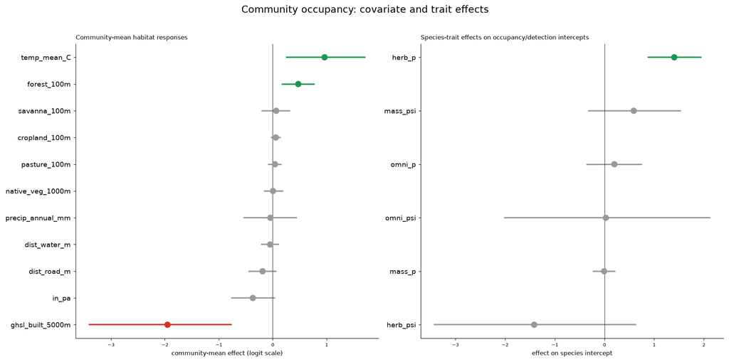

Figura 1: Community occupancy: covariate and trait effects. Left: community-mean habitat responses (logit scale), green = credibly positive, red = credibly negative, grey = credible interval spans zero. Right: species-trait effects on the occupancy and detection intercepts (carnivore is the reference diet class).

Três covariáveis movem a comunidade como um todo. **A cobertura florestal é credivelmente positiva** (μ da comunidade = +0,47, IC 95% [0,17, 0,77]): a espécie média nesse conjunto usa mais sítios florestados. **A temperatura é fortemente positiva** (μ = +0,96, [0,26, 1,71]), refletindo o gradiente tropical-a-subtropical que as redes combinadas abrangem. **O desenvolvimento é credivelmente negativo e é o efeito médio de comunidade mais forte de todo o conjunto** (μ = −1,95, [−3,40, −0,77]): a espécie média nesse conjunto é substancialmente menos propensa a ocorrer perto de superfícies construídas. **O status de área protegida** fica levemente negativo na média da comunidade (μ = −0,37) com um intervalo credível que toca o zero — um não-efeito na média da comunidade que esconde variação real em nível de espécie, o que a próxima figura mostra. As demais covariáveis (savana, pastagem, lavoura, vegetação nativa, precipitação, distância à estrada, distância à água) têm médias de comunidade próximas de zero, mas com *dispersão* não trivial — as espécies discordam entre si, e a média da comunidade elimina essa discordância no cálculo da média.

No lado dos traços, um efeito é credível: **herbívoros têm um intercepto de detecção substancialmente mais alto do que carnívoros** (`herb_p` = +1,40, IC [0,88, 1,94]) — herbívoros de maior porte e mais conspícuos são simplesmente mais fáceis de serem capturados por uma câmera do que carnívoros crípticos, independentemente do habitat. A massa corporal e o contraste de onívoros não são credíveis nem para ocupação nem para detecção, uma vez que a classe de dieta já está no modelo; os herbívoros também mostram uma tendência a um intercepto de ocupação mais baixo (`herb_psi` = −1,41), mas o intervalo ainda abrange o zero.

## 4.3 Respostas em nível de espécie

O modelo de comunidade ainda atribui a cada espécie seus próprios coeficientes — parcialmente compartilhados (pooled), mas específicos de cada espécie. Esta figura mostra todas as 44 espécies para **todas as 11 covariáveis**, dispostas em duas linhas de painéis, já que não cabem em uma única linha, cada painel ordenado de forma independente e colorido de acordo com a credibilidade.

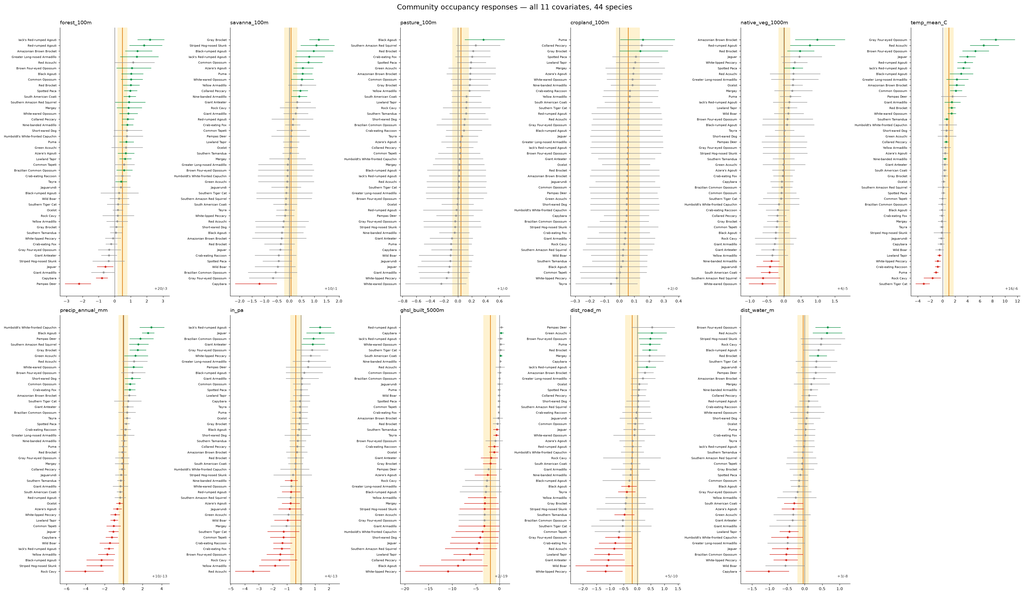

Figura 2: Community occupancy responses. Each panel is one covariate; each row a species; points are posterior means with 95% credible intervals. Green = credibly positive (CrI excludes 0 above), red = credibly negative, grey = CrI spans 0. Yellow band = community-mean 95% CrI; orange line = community mean. The “+n/-n” label in each panel counts credibly-positive/credibly-negative species. Range-masked, 1,092 sites, 44 species.

O painel de floresta é a história mais clara: **23 de 44 espécies respondem credivelmente à floresta, 20 delas positivamente**. Os associados mais fortes à floresta são as cutias (Iack’s Red-rumped Agouti +2,2, Cutia-de-garupa-vermelha +1,8) e o veado-catingueiro amazônico (Amazonian Brown Brocket) (+1,4); as espécies que evitam a floresta são as especialistas em habitat aberto — o veado-campeiro (Pampas Deer) (−2,2) e a capivara (−0,8). A temperatura separa os pequenos marsupiais e roedores (gambá-de-quatro-olhos cinza, cutiara-vermelha) na extremidade quente das espécies subtropicais — gato-do-mato-grande (Southern Tiger Cat), mocó-de-rocha (Rock Cavy) — na extremidade fria. O status de área protegida é onde as espécies mais divergem em torno de uma média de comunidade próxima de zero: algumas espécies ocorrem credivelmente *menos* dentro de áreas protegidas (cutiara-vermelha, tatu-peba (Yellow Armadillo), mocó-de-rocha) — um lembrete de que “protegido no papel” não é o mesmo que “habitat preferido”, e que o sinal de um efeito de proteção é específico da espécie e do contexto.

## 4.4 As covariáveis individuais trocam entre si?

Os painéis acima mostram uma covariável de cada vez. Os cinco gráficos de dispersão duplo (biplots) abaixo, em vez disso, comparam **duas covariáveis ao mesmo tempo, dentro do modelo de comunidade** — perguntando quais espécies trocam quais eixos de habitat entre si. Cada ponto é uma espécie; pontos sólidos grandes são credivelmente significativos para *ambas* as covariáveis, pontos sólidos pequenos para *uma delas*, e pontos vazados para *nenhuma*.

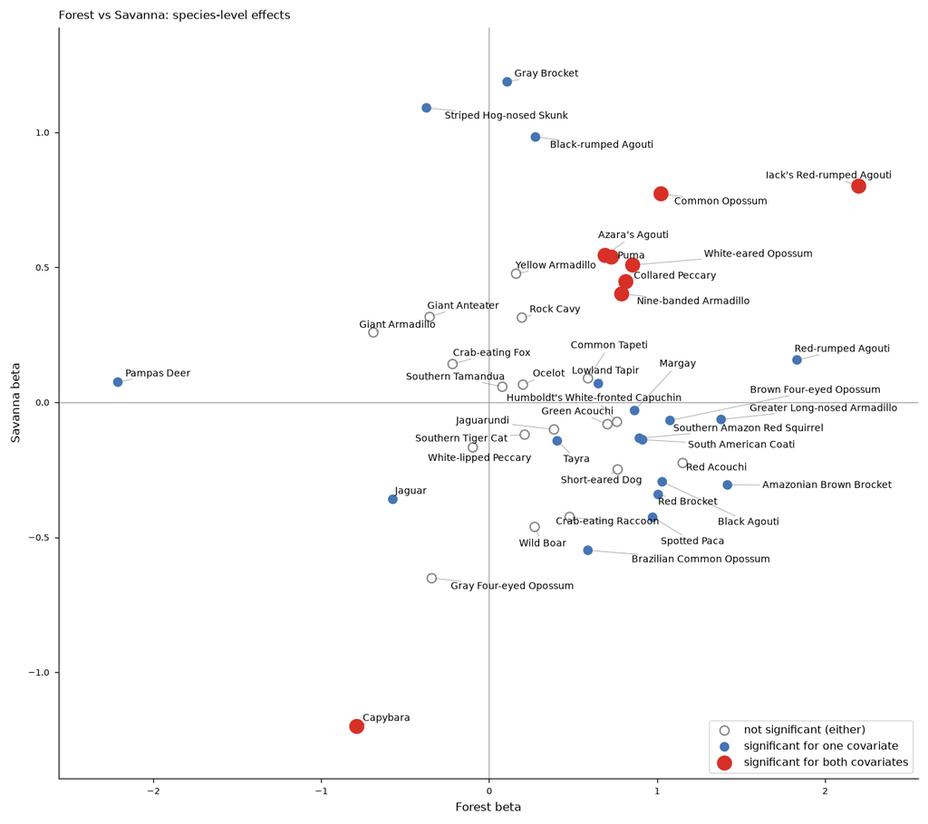

Figura 3: Forest vs Savanna: species-level community occupancy effects.

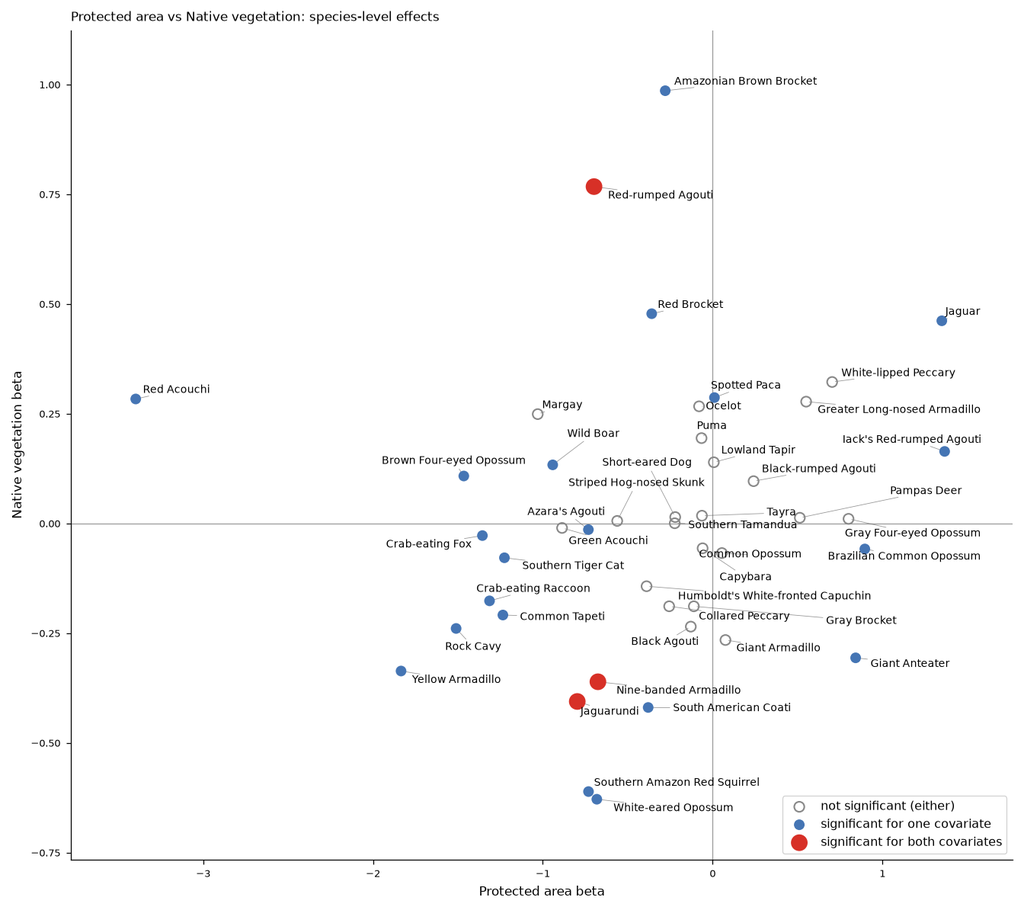

Figura 4: Protected area vs Native vegetation: species-level community occupancy effects.

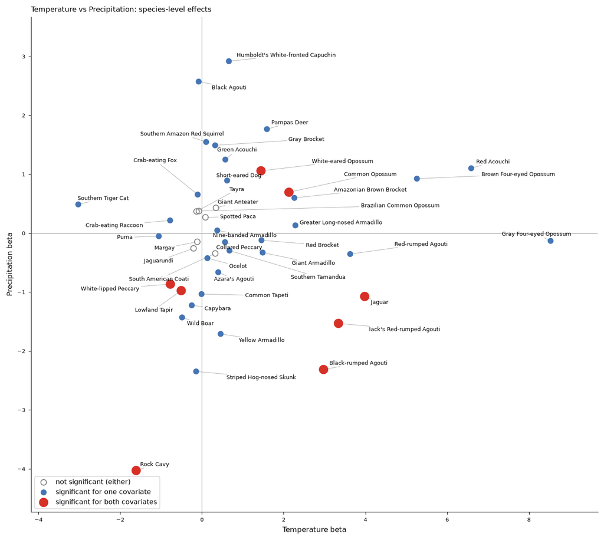

Figura 5: Temperature vs Precipitation: species-level community occupancy effects.

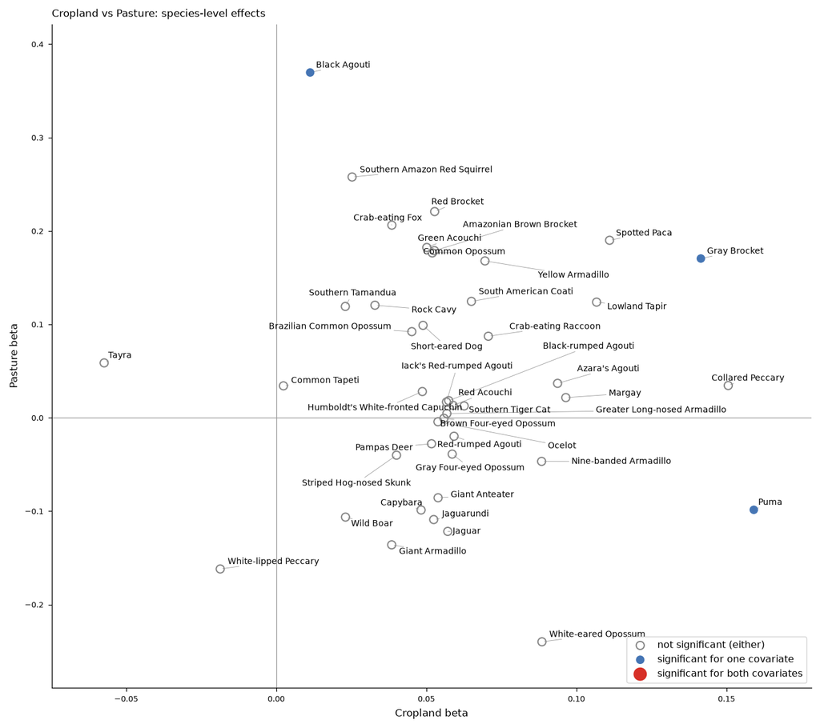

Figura 6: Cropland vs Pasture: species-level community occupancy effects.

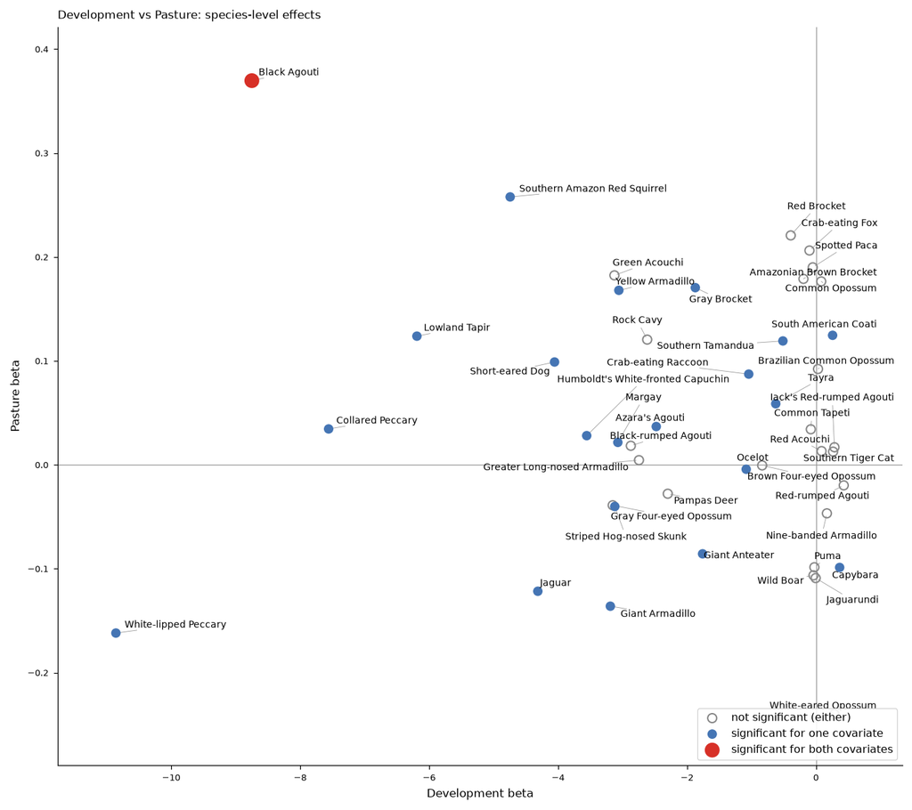

Figura 7: Development vs Pasture: species-level community occupancy effects. Development (`ghsl_built_5000m`) is a **camera-level-only** covariate — it is not in the reduced 6-covariate ARRAY_SET used for array-level models (Module 5), so this panel has no array-level counterpart.

# 5 O modelo conjunto de distribuição de espécies GJAM

## 5.1 A ideia: um mecanismo de recomendação para espécies

O modelo de comunidade ainda trata as espécies como condicionalmente independentes dado o habitat — ele compartilha força entre espécies para *estimar* cada uma delas, mas não pergunta se as espécies co-ocorrem além do que o habitat explica. Um **modelo conjunto de distribuição de espécies** (JSDM) faz isso. O GJAM (Generalized Joint Attribute Model) ajusta todas as espécies juntas e estima uma **correlação residual** entre cada par — a tendência de serem encontradas juntas *depois* de o habitat ter sido levado em conta.

**DicaA analogia do Spotify**

Um serviço de música como o Spotify recomenda músicas de duas formas. A forma óbvia é por **atributos**: você gosta de faixas rápidas e com muita guitarra, então aqui estão mais faixas assim — essa é a parte de *habitat* do nosso modelo, associando uma espécie às características ambientais que ela prefere. Mas a forma poderosa é a **filtragem colaborativa**: “pessoas que gostaram desta música também gostaram daquela”, aprendido puramente a partir de padrões de audição conjunta, sem saber nada sobre as próprias músicas. Um modelo conjunto faz exatamente isso para espécies. Depois de usar o habitat para explicar o que pode, ele observa o que *sobra* — quais espécies continuam aparecendo juntas nas mesmas câmeras com mais frequência do que suas preferências de habitat compartilhadas previam — e interpreta isso como uma associação espécie-a-espécie. A matriz de correlação residual é o equivalente, em armadilhas fotográficas, de “câmeras que fotografaram esta espécie também fotografaram aquela”.

Na prática, o GJAM modela **contagens de detecção** por espécie (uma resposta de abundância discreta), com **noites-câmera como um offset de esforço amostral**, de modo que um sítio observado por 300 noites não seja confundido com um sítio mais rico do que um observado por 30. O habitat entra como covariáveis — as mesmas onze, mais a covariável de distribuição `inrange_frac` (opção 2 acima). O que o modelo de comunidade coloca em uma máscara latente, o GJAM coloca na matriz de design e estima.

```r
# fit_gjam_v2.R (shown for reference; not run in class)
library(gjam)
ml   <- list(typeNames = "DA", ng = 8000, burnin = 2000,   # DA = discrete abundance
             effort = list(columns = 1:S, values = effMat)) # camera-nights offset
form <- ~ forestZ + savannaZ + pastureZ + croplandZ + nvegZ + tempZ + precipZ +
          inPA + builtZ + distroadZ + distwaterZ + inrangeFrac
out  <- gjam(form, xdata = xdata, ydata = counts, modelList = ml)
# out$parameters$betaTable  -> habitat coefficients per species
# out$parameters$corMu      -> residual species co-occurrence matrix
```

## 5.2 Respostas de GJAM aos hábitats

O GJAM estima o mesmo tipo de coeficientes de hábitat que os modelos de ocupação, em sua própria escala (de abundância). O gráfico de barras abaixo substitui uma tabela simples pela mesma informação — mais fácil de visualizar quais covariáveis importam mais, e o quanto.

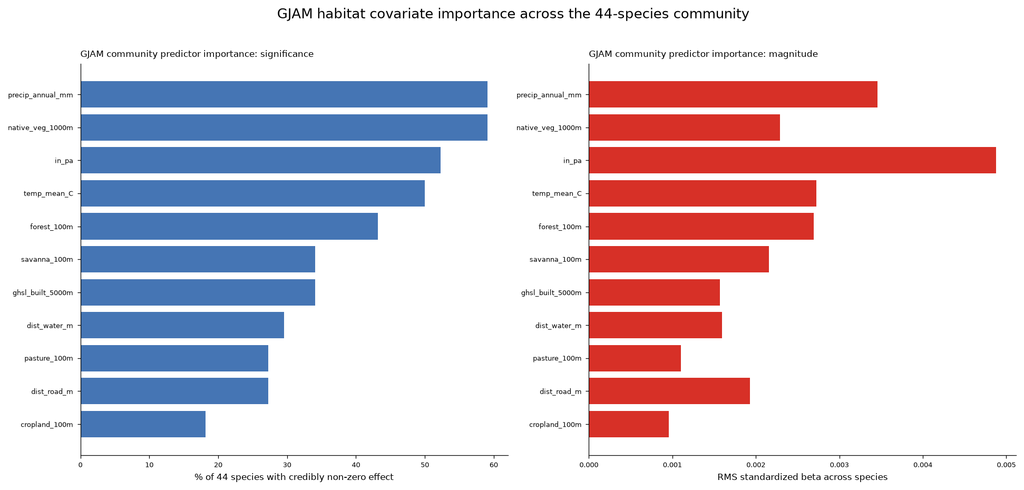

Figura 8: GJAM habitat covariate importance across the 44-species community. Left: the percentage of species with a credibly non-zero coefficient. Right: the RMS (root-mean-square) standardized beta across species — the typical effect *size*, independent of significance. Both panels exclude `inrangeFrac` (a methodological control, not a habitat covariate).

Lidas na escala *padronizada*, as covariáveis que mais movem espécies são precipitação, vegetação nativa e status de área protegida (cada uma significativa para mais da metade da comunidade), com floresta e temperatura logo atrás — em grande parte os mesmos eixos que o modelo de comunidade destacou, o que é tranquilizador: duas famílias de modelos muito diferentes, ajustadas aos mesmos dados, concordam sobre quais gradientes ambientais organizam essa assembleia. Área agrícola (cropland) é a covariável mais fraca em ambos os painéis, consistente com sua escassez na maioria dos sítios.

## 5.3 Co-ocorrência residual entre espécies

Este é o ganho do JSDM — a parte que nenhum modelo de ocupação de espécie única ou de comunidade produz. Depois do hábitat, quais espécies ainda aparecem juntas nas mesmas câmeras mais (ou menos) do que o esperado?

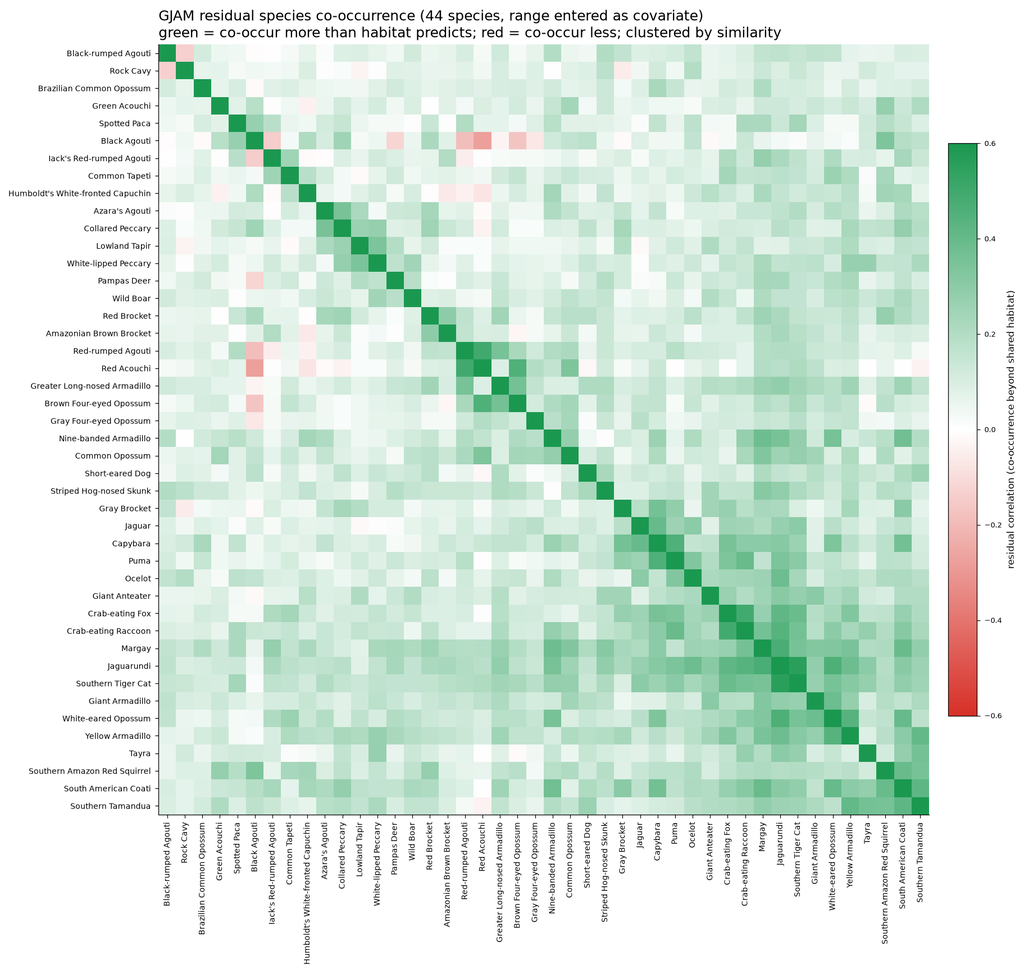

Figura 9: GJAM residual species co-occurrence. Each cell is the residual correlation between two species after habitat and range are accounted for. Green = co-occur more than habitat predicts; red = co-occur less; white ≈ habitat explains it. Species ordered by hierarchical clustering, so blocks of green are groups that associate. 44 species.

```r
rc <- as.matrix(read_d("gjam_residual_correlation_v3.csv")[, -1])
ut <- rc[upper.tri(rc)]
cat("Species pairs:", length(ut),
    "| positive (aggregate):", sum(ut > 0),
    "| negative (segregate):", sum(ut < 0), "\n")
```

```
#> Species pairs: 946 | positive (aggregate): 913 | negative (segregate): 33
```

```r
cat("Residual correlation range:", sprintf("%.2f to %.2f\n", min(ut), max(ut)))
```

```
#> Residual correlation range: -0.27 to 0.56
```

# 6 Importância dos preditores entre métodos

A ideia de importância comunitária do GJAM — quais covariáveis movem mais espécies — generaliza-se para todos os métodos. Aqui está para os cinco, medida da mesma forma independente de unidade: a proporção das 44 espécies com um coeficiente credivelmente não nulo para cada covariável.

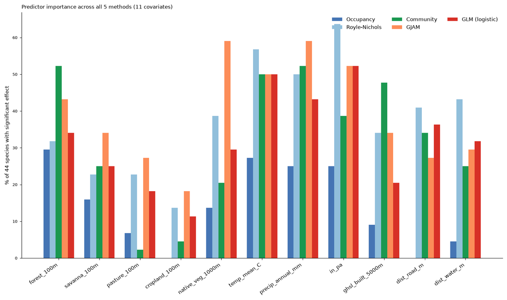

Figura 10: Predictor importance across all 5 methods — the percentage of 44 species with a significant coefficient for each covariate, one bar group per method, across all 11 covariates.

```r
al <- read_d("ecological_coefficients_all_methods_v3.csv")
tab <- dcast(al[, .(pct = round(100*mean(sig))), by = .(covariate, method)],
             covariate ~ method, value.var = "pct")
setcolorder(tab, c("covariate","occupancy","royle_nichols","community","gjam","glm"))
knitr::kable(tab, caption = "% of 44 species with a significant effect, by covariate and method.")
```

% of 44 species with a significant effect, by covariate and method.

| covariate | occupancy | royle_nichols | community | gjam | glm |
| --- | --- | --- | --- | --- | --- |
| cropland_100m | 0 | 14 | 5 | 18 | 11 |
| dist_road_m | 0 | 41 | 34 | 27 | 36 |
| dist_water_m | 5 | 43 | 25 | 30 | 32 |
| forest_100m | 30 | 32 | 52 | 43 | 34 |
| ghsl_built_5000m | 9 | 34 | 48 | 34 | 20 |
| in_pa | 25 | 64 | 39 | 52 | 52 |
| native_veg_1000m | 14 | 39 | 20 | 59 | 30 |
| pasture_100m | 7 | 23 | 2 | 27 | 18 |
| precip_annual_mm | 25 | 50 | 52 | 59 | 43 |
| savanna_100m | 16 | 23 | 25 | 34 | 25 |
| temp_mean_C | 27 | 57 | 50 | 50 | 50 |

## 6.1 Os métodos concordam quanto a espécies individuais?

As barras de importância resumem entre espécies; os biplots abaixo fazem a pergunta mais fina, uma espécie de cada vez, para o efeito de floresta (o sinal mais forte). Cada ponto é uma espécie; a linha pontilhada é a concordância 1:1. Como os métodos vivem em escalas diferentes (ocupação logit, abundância log, contagens ajustadas por esforço do GJAM), cada eixo é padronizado entre espécies para que a linha 1:1 seja significativa.

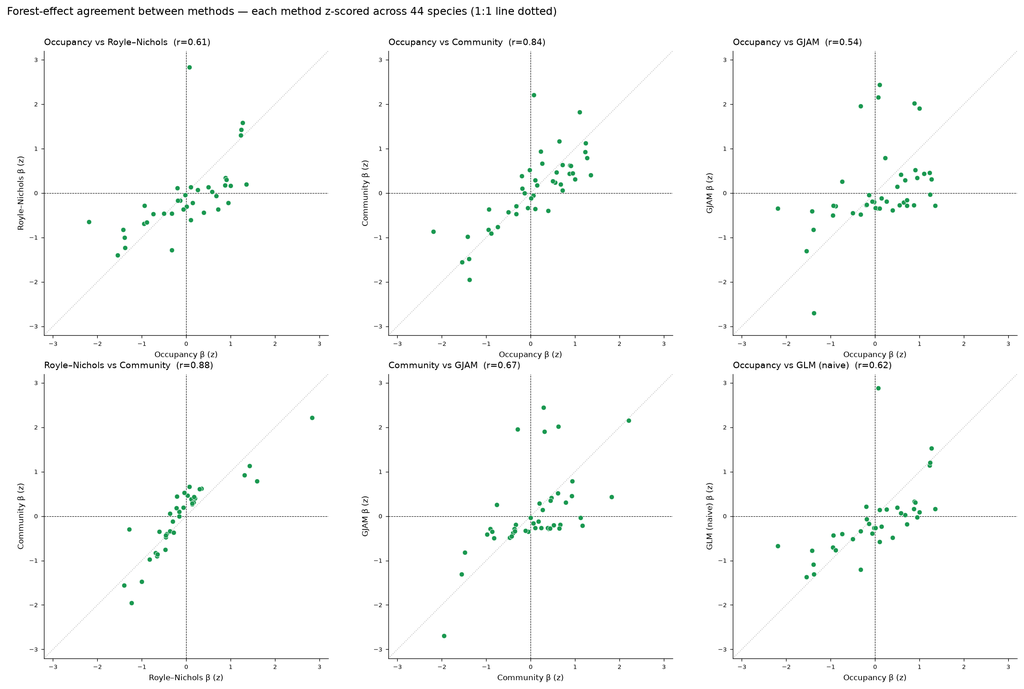

Figura 11: Forest-effect agreement between every pair of methods, each method z-scored across the 44 species. Points near the 1:1 dotted line mean the two methods rank species the same way. The detection-corrected occupancy-family methods (occupancy, Royle–Nichols, community) agree most tightly; GJAM, which estimates a different quantity, agrees least.

```r
cc <- read_d("method_beta_correlations_v3.csv")
knitr::kable(cc[order(-r), .(method_a, method_b, r, n)],
             caption = "Pairwise correlation of coefficients across all species × covariates (GLM separation outliers removed).")
```

Pairwise correlation of coefficients across all species × covariates (GLM separation outliers removed).

| method_a | method_b | r | n |
| --- | --- | --- | --- |
| royle_nichols | glm | 0.9695717 | 420 |
| community | glm | 0.7490991 | 420 |
| occupancy | community | 0.6346089 | 484 |
| royle_nichols | community | 0.6291343 | 438 |
| occupancy | gjam | 0.5958304 | 484 |
| occupancy | glm | 0.4278658 | 420 |
| community | gjam | 0.4195236 | 484 |
| occupancy | royle_nichols | 0.3553937 | 438 |
| gjam | glm | 0.2345536 | 420 |
| royle_nichols | gjam | 0.2006020 | 438 |

# 7 Conclusões

**NotaO que fica para módulos posteriores**

- **Interações entre espécies** — a leitura da matriz residual do GJAM como uma rede de interações, os modelos de interação baseados em abundância, e o grafo completo de co-ocorrência — são o **Módulo 6**.
- **Projetar esses modelos ajustados em mapas** por todo o Brasil, com as verificações de adequação do modelo e de cobertura de covariáveis, é o **Módulo 5 (Predição & mapeamento)**.

*Insumos pré-computados (carregados acima): `community_species_betas_v3.csv`, `community_hyperparameters_v3.csv`, `community_trait_effects.csv`, `gjam_habitat_betas_v3.csv`, `gjam_predictor_importance_v3.csv`, `gjam_residual_correlation_v3.csv`, `ecological_coefficients_all_methods_v3.csv` (formato longo), `method_beta_correlations_v3.csv`, `range_mask_v2.csv`, e as figuras `community_responses_full.png`, `gjam_importance_bars.png`, `gjam_residual_correlation.png`, `methods_importance_v3.png`, `method_pair_biplots.png`, e os cinco biplots de pares de covariáveis (`biplot_forest_savanna.png`, `biplot_in_native.png`, `biplot_temp_precip.png`, `biplot_cropland_pasture.png`, `biplot_ghsl_pasture.png`). Os traços das espécies (log da massa corporal, classe de dieta) vêm do banco de dados de traços de mamíferos COMBINE (Soria et al. 2021), combinados via taxonomia MDD. Os modelos conjuntos não são reajustados aqui; defina `run_live: true` apenas para reajustar fora da aula (modelo de comunidade ≈ 8 h, GJAM ≈ 20 min).*